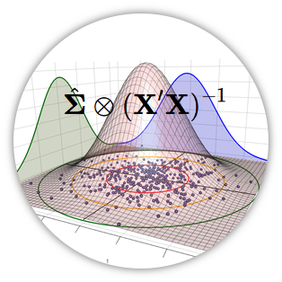

#### Multivariate Covariance Generalized Linear Models for the Analysis of Experimental Data

##### [`github.com/leg-ufpr/mcglm4aed`](https://github.com/leg-ufpr/mcglm4aed)

# Multivariate analysis of Gaussian data (MANOVA)

Part I

Wagner H. Bonat Walmes M. Zeviani `wbonat@ufpr.br` `walmes@ufpr.br` LEG/DEST/UFPR LEG/DEST/UFPR

62<sup>a</sup> RBras & 17<sup>o</sup> SEAGRO July 24–28, 2017 UFLA, Lavras/MG

# 1 Motivational data sets

## 1.1 `iris` data set

- `iris` data set was collected by Anderson (1935) on three species of irises in the Gaspé Peninsula of Quebec, Canada.
- This data set was employed by R. A. Fisher (1936) to introduce the method of discriminant analysis.
- Easily available in $\textsf{R}$ through `data(iris)`.
- Four response variables representing measurements (in cm) of parts of the flowers (length and width of sepal and petal).
- One experimental factor with three levels `setosa`, `versicolor` and `virginica` representing the species of iris.
- How the species are related with flowers size?
- Size is not a really precise response variable and can be understood as a function of the four measured response variables.

```r
data(iris)

scatterplotMatrix(~Sepal.Length + Sepal.Width +
                      Petal.Length + Petal.Width | Species,
                  data = iris,
                  smooth = FALSE,
                  reg.line = FALSE,
                  ellipse = TRUE,
                  by.groups = TRUE,
                  diagonal = "none",
                  legend.pos = "bottomleft")
```

[output not shown]

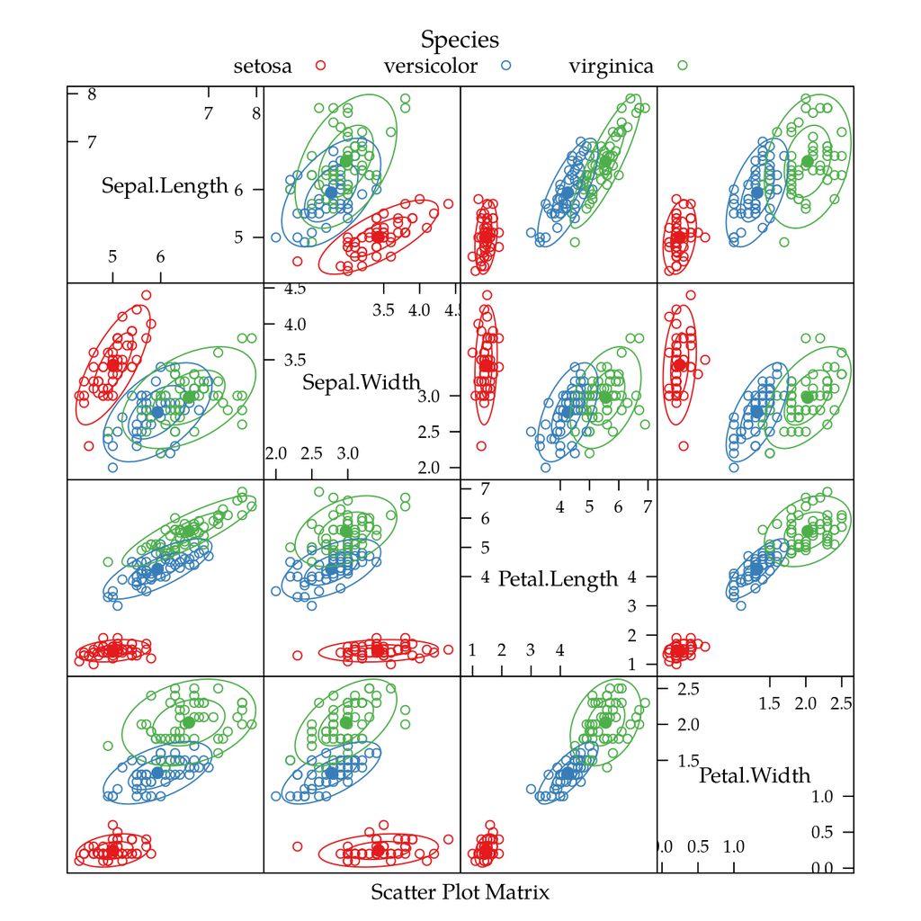

```r
panel.ell <- function(x, y, ...) {
    panel.xyplot(x, y, ...)
    panel.ellipse(x, y, level = 0.5,
                  center.pch = 19, center.cex = 1, ...)
    panel.ellipse(x, y, level = 0.9,
                  center.pch = 19, center.cex = 1, ...)
}

splom(~iris[1:4],
      data = iris,
      as.matrix = TRUE,
      auto.key = list(columns = 3,
                      title = "Species",
                      cex.title = 1.1),
      groups = Species,
      lower.panel = panel.ell,
      upper.panel = panel.ell)
```

## 1.2 `soya` data set

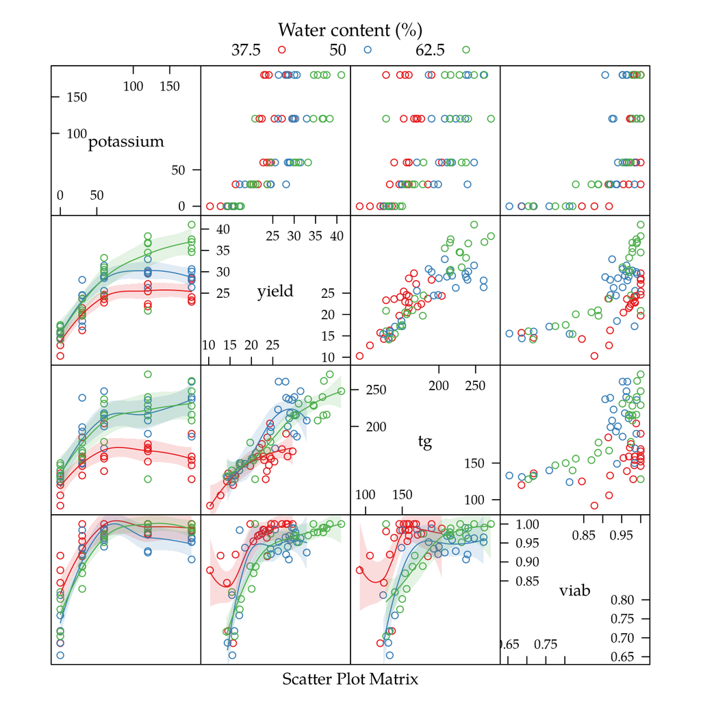

```r
data(soybeanwp, package = "wzRfun")
str(soybeanwp)

soybeanwp$viab <- with(soybeanwp, nvp/(nvp + nip))

splom(~soybeanwp[, c(1, 4, 7, 10)],
      #~soybeanwp[, c(1, 4:7, 10)],
      groups = soybeanwp$water,
      as.matrix = TRUE,
      lower.panel = function(x, y, groups, ...) {
          panel.xyplot(x, y, groups = groups, ...)
          i <- 0
          by(cbind(x, y),
             INDICES = groups,
             FUN = function(m) {
                 i <<- i + 1
                 panel.smoother(x = m[, 1],
                                y = m[, 2],
                                span = 0.9,
                                alpha.se = 0.15,
                                col = trellis.par.get()$superpose.line$col[i])
             })
      },
      auto.key = list(columns = 3,
                      title = "Water content (%)",
                      cex.title = 1.1))
```

```r
# str(soybeanwp)

# Fitting the same model to all response variables.
m0 <- lm(cbind(yield, w100, Kconc, tg, viab) ~
             block + water * factor(potassium),
         data = soybeanwp)

r <- residuals(m0)
```

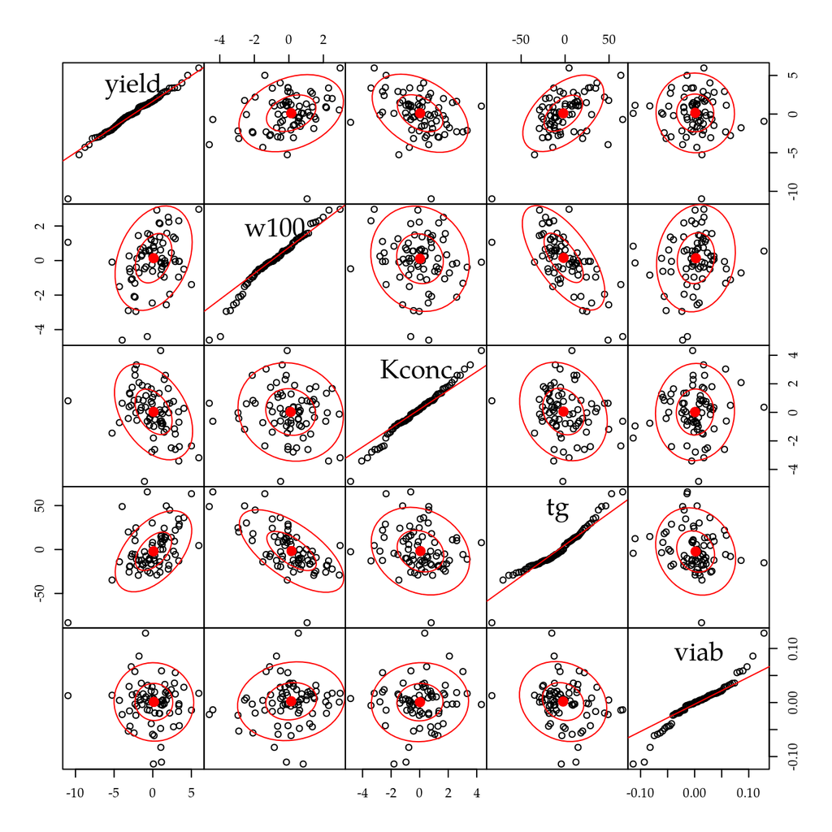

```r
# Change the 3rd color of the palette used for the ellipses.
oldpal <- palette()
palette(c("black", "blue", "red"))
scatterplotMatrix(r,
                  gap = 0,
                  smooth = FALSE,
                  reg.line = FALSE,
                  ellipse = TRUE,
                  diagonal = "qqplot")
```

```r
palette(oldpal)
```

## 1.3 Motivation and research questions

# 2 Part I: Multivariate analysis of Gaussian data

## 2.1 General multivariate linear model

### 2.1.1 Matrix notation

$$\mathrm{Y} = \mathrm{X}\mathbf{B} + \mathbf{E}$$

$$\begin{pmatrix}
Y_{11} & \ldots & Y_{1R}\\
\vdots & \ddots & \vdots \\
Y_{N1} & \ldots & Y_{NR}
\end{pmatrix} =
\begin{pmatrix}
x_{11} & \ldots & x_{1k}\\
\vdots & \ddots & \vdots \\
x_{N1} & \ldots & x_{Nk}
\end{pmatrix}
\begin{pmatrix}
\beta_{01} & \ldots & \beta_{0R}\\
\vdots & \ddots & \vdots \\
\beta_{k1} & \ldots & \beta_{kR}
\end{pmatrix} +
\begin{pmatrix}
\epsilon_{11} & \ldots & \epsilon_{1R}\\
\vdots & \ddots & \vdots \\
\epsilon_{N1} & \ldots & \epsilon_{NR}
\end{pmatrix}$$

- $\mathrm{Y}$ is a matrix of $N$ observations on $R$ response variables.
- $\mathrm{X}$ is an $(N \times k)$ model matrix with collumns for $k$ regressors (experimental factors).
- $\mathrm{B}$ is a $(k \times R)$ matrix of regression coefficients.
- $\mathrm{E}$ is an $(N \times R)$ matrix of errors, such that $\epsilon^{\top}_i \sim N_{R}(\mathbf{0}, \Sigma)$.
- $\Sigma$ is an ($R \times R$) covariance matrix, constant across observations, i.e.

$$\Sigma =
\begin{pmatrix}
\sigma_{11} & \ldots & \sigma_{1R} \\
\vdots & \ddots & \vdots \\
\sigma_{R1} & \ldots & \sigma_{RR}
\end{pmatrix}.$$

### 2.1.2 Least squares estimators for regression coefficients

$$\hat{\mathrm{B}} =
(\mathrm{X}^{\top}\mathrm{X})^{-1}
\mathrm{X}^{\top}\mathrm{Y}.$$

$\Sigma$ can be estimated by the empirical covariance matrix

$$\hat{\Sigma} =
\frac{(\mathrm{Y} - \mathrm{X} \hat{\mathrm{B}})^{\top}
(\mathrm{Y} - \mathrm{X} \hat{\mathrm{B}})}{n}.$$

## 2.2 R code

```r
data(iris)
head(iris)
```

```
##   Sepal.Length Sepal.Width Petal.Length Petal.Width Species
## 1          5.1         3.5          1.4         0.2  setosa
## 2          4.9         3.0          1.4         0.2  setosa
## 3          4.7         3.2          1.3         0.2  setosa
## 4          4.6         3.1          1.5         0.2  setosa
## 5          5.0         3.6          1.4         0.2  setosa
## 6          5.4         3.9          1.7         0.4  setosa
```

```r
# Response variable matrix.
# Y <- as.matrix(iris[, 1:4], ncol = 4, nrow = 150)
Y <- as.matrix(iris[, 1:4])
dim(Y)
```

```
## [1] 150   4
```

```r
# Design matrix.
X <- model.matrix(~Species, data = iris)

# Regression coefficients (don't try this at home, children).
B <- solve(tcrossprod(t(X))) %*% t(X) %*% Y
B
```

```
##                   Sepal.Length Sepal.Width Petal.Length Petal.Width
## (Intercept)              5.006       3.428        1.462       0.246
## Speciesversicolor        0.930      -0.658        2.798       1.080
## Speciesvirginica         1.582      -0.454        4.090       1.780
```

```r
# Covariance matrix.
# Sigma <- t(Y - X %*% B) %*% (Y - X %*% B)/nrow(iris)
E <- Y - X %*% B
Sigma <- crossprod(E)/nrow(iris)
Sigma
```

```
##              Sepal.Length Sepal.Width Petal.Length Petal.Width
## Sepal.Length   0.25970800  0.09086667   0.16416400  0.03763333
## Sepal.Width    0.09086667  0.11308000   0.05413867  0.03205600
## Petal.Length   0.16416400  0.05413867   0.18148400  0.04181200
## Petal.Width    0.03763333  0.03205600   0.04181200  0.04104400
```

```r
# Correlation matrix
cov2cor(Sigma)
```

```
##              Sepal.Length Sepal.Width Petal.Length Petal.Width
## Sepal.Length    1.0000000   0.5302358    0.7561642   0.3645064
## Sepal.Width     0.5302358   1.0000000    0.3779162   0.4705346
## Petal.Length    0.7561642   0.3779162    1.0000000   0.4844589
## Petal.Width     0.3645064   0.4705346    0.4844589   1.0000000
```

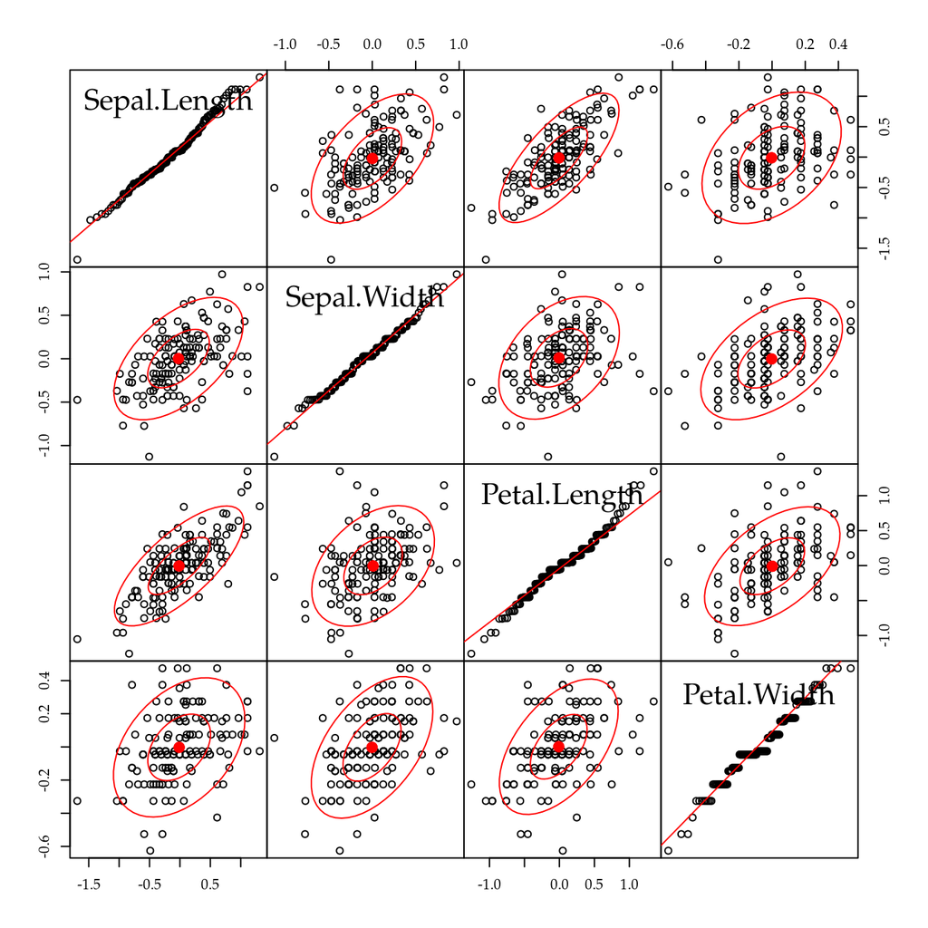

```r
# Change the 3rd color of the palette used for the ellipses.
oldpal <- palette()
palette(c("black", "blue", "red"))
scatterplotMatrix(E,
                  gap = 0,
                  smooth = FALSE,
                  reg.line = FALSE,
                  ellipse = TRUE,
                  diagonal = "qqplot")
```

```r
palette(oldpal)
```

## 2.3 Model-based approach

- Let $\mathcal{Y} = (Y_1^{'}, \ldots, Y_R^{'})^{'}$ be the stacked vector $(NR \times 1)$ of the outcome matrix $\mathbf{Y}_{N \times R}$ by columns.
- Let $\mathbf{X} = \mathrm{Bdiag}(\mathrm{X}_1, \ldots, \mathrm{X}_R)$ be an $(NR \times k)$ design matrix, where the operator $\mathrm{Bdiag}$ denotes a block diagonal matrix whose entries are given by $\mathrm{X}$.
- We can easily extend to the case where $\mathrm{X}$ is different for each response variable.
- Let $\boldsymbol{\beta} = (\beta_1^{'}, \ldots, \beta_R^{'})^{'}$ be the stacked vector $(K \times 1)$ of the regression parameters matrix $\mathbf{B}$ by columns.
- General linear model
  $$\mathcal{Y} \sim \mathrm{N}_{NR}(\mathbf{X}\boldsymbol{\beta},
  \Sigma \otimes \mathrm{I}_N)$$
  where $\mathrm{I}_N$ denotes an $(N \times N)$ identity matrix and $\otimes$ denotes the Kronecker product.
- Equivalently, we have
  $$\mathcal{Y} = \mathbf{X}\boldsymbol{\beta} + \boldsymbol{\epsilon}$$
  where $\boldsymbol{\epsilon} \sim \mathrm{N}_{NR}(\boldsymbol{0}, \Sigma \otimes \mathrm{I})$.
- It can be shown that
  $$\begin{aligned}
  \mathrm{E}(\mathcal{Y}) &= \mathbf{X}\boldsymbol{\beta},\\
  \mathrm{var}(\mathcal{Y}) &= \Sigma \otimes \mathrm{I}.
  \end{aligned}$$
- For simplicity denote $\Omega = \Sigma \otimes \mathrm{I}.$

## 2.4 Maximum likelihood estimation

- Likelihood function
  $$L(\boldsymbol{\beta}, \Omega) =
  (2\pi)^{ -\frac{NR}{2} } |\Omega|^{-\frac{1}{2}}
  \exp \left\{
  -\frac{1}{2}
  (\mathcal{Y} - \mathbf{X}\boldsymbol{\beta})^{'}
  \Omega^{-1}
  (\mathcal{Y} - \mathbf{X}\boldsymbol{\beta})
  \right\}.$$
- Log-likelihood function
  $$l(\boldsymbol{\beta}, \Omega) =
  -\frac{NR}{2}\log(2\pi)
  -\frac{1}{2}\log |\Omega|
  -\frac{1}{2}(
  \mathcal{Y} - \mathbf{X}\boldsymbol{\beta})^{'}
  \Omega^{-1}
  (\mathcal{Y} - \mathbf{X}\boldsymbol{\beta}).$$
- Score function for $\boldsymbol{\beta}$ is given by
  $$U_{\boldsymbol{\beta}}(\boldsymbol{\beta}, \Omega) =
  \frac{\partial l(\boldsymbol{\beta}, \Omega)}{
  \partial \boldsymbol{\beta}} =
  \mathbf{X}^{'} \Omega^{-1}
  (\mathcal{Y} - \mathbf{X}\boldsymbol{\beta}).$$
- Maximum likelihood estimator (MLE) for $\boldsymbol{\beta}$
  $$\hat{\boldsymbol{\beta}} =
  (\mathbf{X}^{'}\mathbf{X})^{-1}\mathbf{X}^{'}\mathcal{Y}.$$
- Fisher Information Matrix for $\boldsymbol{\beta}$
  $$\mathcal{F}_{\boldsymbol{\beta}} =
  \mathbf{X}^{'}\Omega^{-1}\mathbf{X}.$$
- Let $\boldsymbol{\sigma}$ be the stacked vector $(Q \times 1)$ of the covariance parameters matrix $\Omega$ by columns.
- We introduce the notation $\Omega(\boldsymbol{\sigma})$ to emphasize that $\Omega$ is composed by the components of $\boldsymbol{\sigma}$.
- Score function for the component $\sigma_{i}$ is given by
  $$\begin{aligned}
  U_{\sigma_{i}}(\boldsymbol{\beta}, \Omega(\boldsymbol{\sigma})) &=
  \frac{
  \partial l(\boldsymbol{\beta}, \Omega(\boldsymbol{\sigma}))}{
  \partial \sigma_{i}}\\
  &= -\frac{1}{2} \left\{
  \Omega(\boldsymbol{\sigma})^{-1}
  - \Omega(\boldsymbol{\sigma})^{-1}
  (\mathcal{Y} - \mathbf{X}\boldsymbol{\beta})
  (\mathcal{Y} - \mathbf{X}\boldsymbol{\beta})^{'}
  \Omega(\boldsymbol{\sigma})^{-1}
  \right\}
  \frac{
  \partial \Omega(\boldsymbol{\sigma})}{
  \partial \sigma_{i}}.
  \end{aligned}$$
- After some calculation, we can show that the MLE for $\Omega$ is given by
  $$\hat{\Omega} = \hat{\Sigma} \otimes \mathrm{I},$$
  where $\hat{\Sigma}$ is the empirical covariance matrix.
- The $(i, j)$ entry of the Fisher Information matrix for the components $\sigma_i$ and $\sigma_j$ is given by
  $$\mathcal{F}_{\sigma_i \sigma_j} =
  \frac{1}{2}\mathrm{tr}(\mathrm{W}_{\sigma_i}
  \Omega (\boldsymbol{\sigma}) \mathrm{W}_{\sigma_j}
  \Omega (\boldsymbol{\sigma})),$$
  where $\mathrm{W}_{\sigma_i} = -\frac{ \partial \Omega(\boldsymbol{\sigma})^{-1}}{\partial \sigma_i}$.
- Let $\mathcal{F}_{\boldsymbol{\sigma}}$ be the $Q \times Q$ Fisher information matrix for the vector $\boldsymbol{\sigma}$.
- It can be shown that $\boldsymbol{\beta}$ and $\boldsymbol{\sigma}$ are orthogonal.
- Fisher information matrix for $\boldsymbol{\theta} = (\boldsymbol{\beta}^{'}, \boldsymbol{\sigma}^{'})^{'}$ is given by
  $$\mathcal{F}_{\boldsymbol{\theta}} =
  \begin{pmatrix}
  \mathcal{F}_{\boldsymbol{\beta}} & \boldsymbol{0} \\
  \boldsymbol{0} & \mathcal{F}_{\boldsymbol{\sigma}}
  \end{pmatrix}.$$
- Asymptotic distribution of the MLE
  $$\hat{\boldsymbol{\theta}}
  \sim N_{P+Q}(\boldsymbol{\theta},
  \mathcal{F}_{\boldsymbol{\theta}}^{-1}).$$

## 2.5 R code

```r
# Loading data set.
data(iris)

# Fitting the model (R = 4 response variables).
fit1 <- lm(cbind(Sepal.Length,
                 Sepal.Width,
                 Petal.Length,
                 Petal.Width) ~ Species,
           data = iris)

# Estimated regression coefficients (\beta).
coef(fit1)
```

```
##                   Sepal.Length Sepal.Width Petal.Length Petal.Width
## (Intercept)              5.006       3.428        1.462       0.246
## Speciesversicolor        0.930      -0.658        2.798       1.080
## Speciesvirginica         1.582      -0.454        4.090       1.780
```

```r
# Estimated covariance matrix (\Sigma).
cov(residuals(fit1))
```

```
##              Sepal.Length Sepal.Width Petal.Length Petal.Width
## Sepal.Length   0.26145101  0.09147651   0.16526577  0.03788591
## Sepal.Width    0.09147651  0.11383893   0.05450201  0.03227114
## Petal.Length   0.16526577  0.05450201   0.18270201  0.04209262
## Petal.Width    0.03788591  0.03227114   0.04209262  0.04131946
```

- It provides exactly the same estimates that separate calls to the `lm()` function.
- Standard errors for regression coefficients are available through the function `vcov()`.
- Standard errors for covariance coefficients are not available.

## 2.6 Next topics

- Reapeted measures design.
- Profile analysis.
- Analysis for the canonical variates.
- Multiple comparisons procedures.
- Checking model assumptions.
- Multiple design linear regression models.

# 3 References

| [`mcglm4aed` - Multivariate Covariance Generalized Linear Models for the Analysis of Experimental Data](https://github.com/leg-ufpr/mcglm4aed) | Bonat & Zeviani (2017) |
| --- | --- |